# Trellis Plots

Getting Started

Paul Johnson

Center for Research Methods and Data Analysis, University of Kansas  
pauljohn@ku.edu

CRMDA Guide #45. Please visit http://crmda.ku.edu/guides for updates.

Tags: guides, R, graphics, trellis plots

2017 March 06

Abstract

In multi-level modeling, it is very common to subdivide the data into subgroups for the creation of graphs. The “trellis” plot, poineered by Wm. Cleveland, was first offered in S+. Since then, many programs have implemented functions to generate this same type of plot.

## Example data

The High School and Beyond data set summarizes mathematical and English language achievement for students. I have instructions about downloading and importing that data on this web page:

http://pj.freefaculty.org/guides/stat/DataSets/HSB/00-README.txt

The following will download a copy of the data if one is not already available in the working directory.

```r
if (file.exists("hsb.rds")){
    hsb <- readRDS("hsb.rds")
} else {
    library(foreign)
    hsb.url <- "http://www.stata-press.com/data/mlmus3/hsb.dta"
    hsb <- read.dta(hsb.url)
    saveRDS(hsb, "hsb.rds")
}
hsb$schoolidf <- factor(hsb$schoolid)
```

## R packages for trellis plots

1 `coplot` in base R. Syntax: y ~ x | z, where z is the grouping variable.

```r
#coplot(mathach ~ ses | schoolidf, hsb)
```

Choose sample of 27 schools

```r
#id27 <- sample(x = unique(hsb$schoolid), size = 27)
#hsbsub <- hsb[hsb$schoolid %in% id27, ]
#coplot(mathach ~ ses | schoolidf, hsbsub)
```

Now “unused levels” in schoolidf must be dropped for purpose of analysis

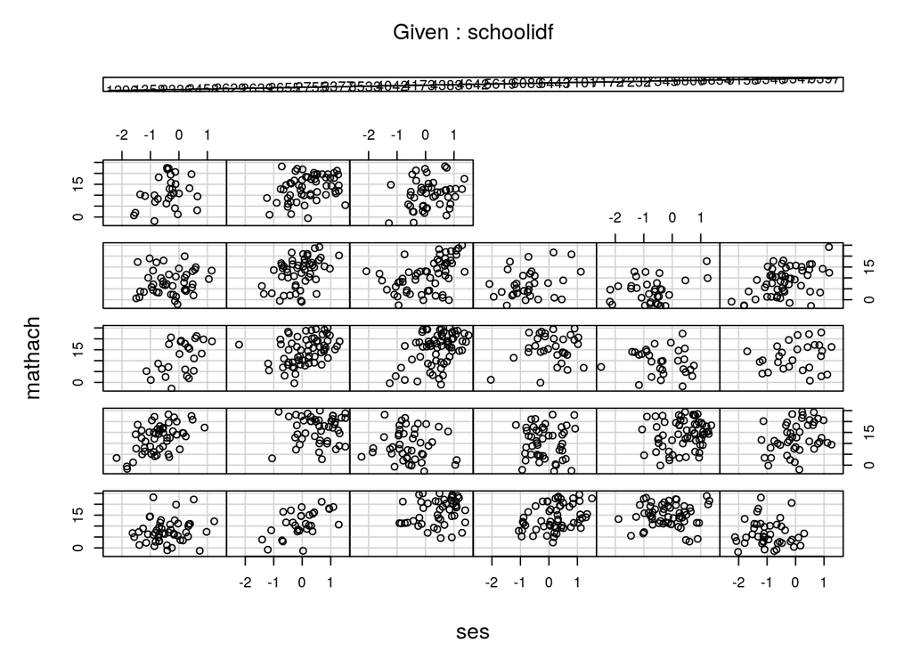

```r
id27 <- sample(x = unique(hsb$schoolid), size = 27)
hsbsub <- hsb[hsb$schoolid %in% id27, ]
hsbsub$schoolidf <- factor(hsbsub$schoolidf)
coplot(mathach ~ ses | schoolidf, hsbsub)
```

2 `lattice` package

Fearing that usage of the name “trellis” might invite either confusion or complaint from ATT, the early R facility to do same sort of graph was named “lattice”. Development work was done by U. Wisconsin Deepayan Sarkar, who wrote a book about it named *Lattice: Multivariate Data Visualization with R* (Springer, 2008).

The workhorse function for 2D plots is `xyplot`.

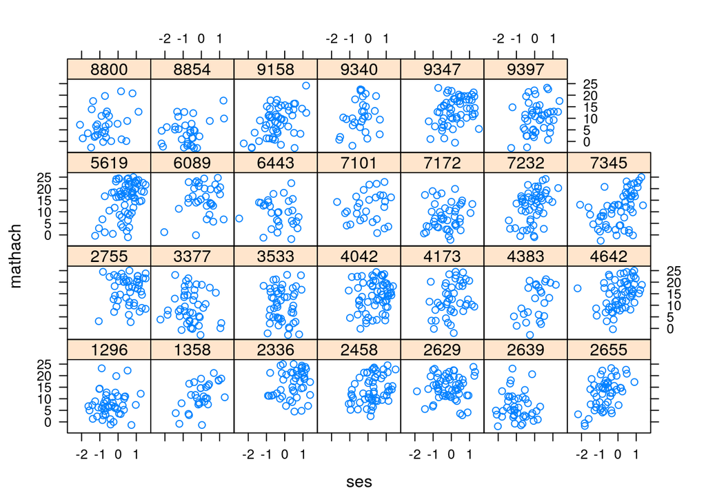

```r
library(lattice)
xyplot(mathach ~ ses | schoolidf, hsbsub)
```

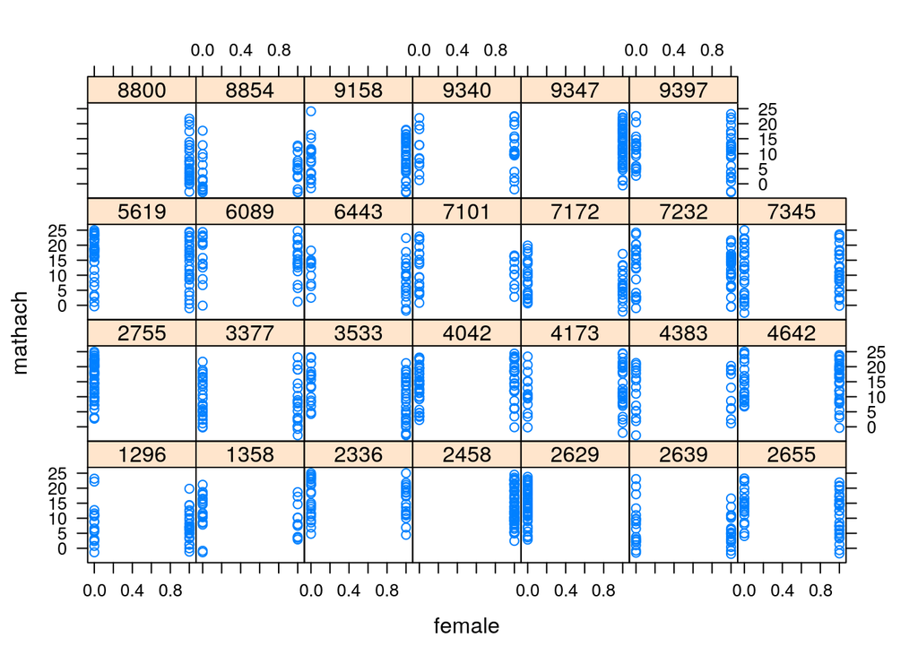

```r
xyplot(mathach ~ female | schoolidf, hsbsub)
```

The style of the presentation is patterned after the original ATT trellis graphs:

1. School ID printed in small title box for each display
2. default plot for numeric variables is a scatterplot
3. Tightly placed subplots with no space between
4. Re-use axes to avoid clutter

The design of the lattice function is intricate. It is possible to add features within each panel.

Like R base plots, xyplot will try to detect the variable types being used and adjust accordingly. Note the difference between the xyplot using female as a numeric variable code 0 or 1

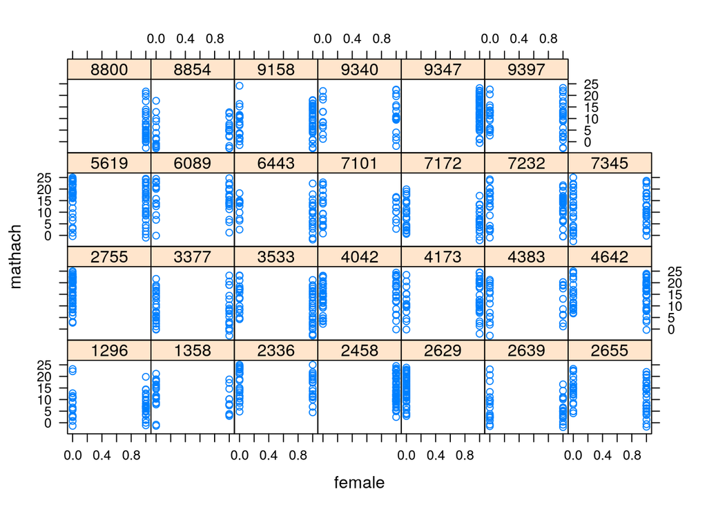

```r
xyplot(mathach ~ female | schoolidf, hsbsub)
```

and the xyplot in which the factor gender is used.

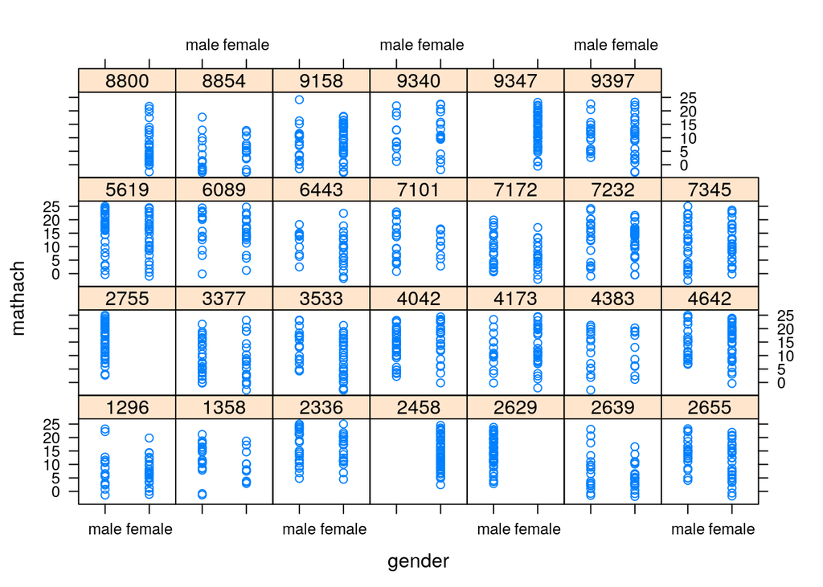

```r
hsbsub$gender <- factor(hsbsub$female, levels = c(0,1), labels = c("male", "female"))
xyplot(mathach ~ gender | schoolidf, hsbsub)
```

Please read the manual, `?xyplot`. As one can see, there is a very elaborate design that allows one to add detailed features within each subplot.

Over the past few years, several of our graduate students have mastered lattice graphics. I have to admit, I find it rather difficult to wrap all of the required code into a single very large function call. That reluctance about `lattice` is somewhat widely shared, it was one of the motivations for development of alternative plotting frameworks. The leading alternative at the current time is `ggplot2`

3. `ggplot2`

One of the themes is that people who make graphics should be guided by a more formal, carefully elucidated framework. Hence the reliance on recommendations in the book, *The Grammar of Graphics*, from which the “gg” in the package’s title eminates.

The main difference between lattice and ggplot2 is in the style with which individual plot pieces are added.

- In lattice, one writes a single, large function call that adds all of the elements
- ggplot2, like R base plots, allows one to add individual plot elements, one at a time.

The original ggplot syntax, to which I am still partial, resembles object oriented programming. For example

```
p <- ggplot(...code here...)
p <- p + ggplot_function(...more code here...)
p <- p + ggplot_function(...more code here...)
```

While that is my favorite way, the youngsters seem to prefer to write out the plot as a long sum of statements, like this:

```
p <- ggplot(...code here...)
     + ggplot_function(...more code here...)
     +  ggplot_function(...more code here...)
```

## Stata

Stata is not my preferred graphics framework. I learned these examples by studying Rabe-Hesketh & Skrondal’s book, *Multilevel and Longitudinal Modeling using Stata*.

The Stata framework for trellis graphics is rather closer to the R lattice package than to base R graphics or ggplot2. One can create an initial plot and then add features in parentheses after that.

One interesting feature is that Stata uses the same basic command to produce a plot for a single sample and for many subsamples.

### Explore twoway: Simple Scatterplot in Stata

- Scatterplot

Suppose we have columns y, x, and yhat (predicted values from regression).

#### twoay (line..) versus twoway (scatter…)

```
regress y x
predict yhat, xb
twoway (scatter y x)
```

- Add a regression line

  ```
  twoway (scatter y x)(line yhat x, sort)
  ```

- Embellish with axis titles

  ```
  twoway (scatter y x)(line yhat x, sort), ytitle(my y var is),
  xtitle(my xvar is)
  ```

These examples work well if there is one sample, not separate groups. For multiple groups, we need the trellis graph

### Trellis

Suppose there is a grouping variable z

add a comma, then by `, by(z)`

I generally do not want the extra space that inserts, so by habit I insert `,by(z compact)`

```
twoway (scatter y x)(lfit y x, sort lpatt(solild)), ///
by(z, compact legend(off) cols(5)) ///
xtitle(whatever) ytitle(somethingelse) ysize(3) xsize(2)
```

### Examples to run for example

Illustration:

1. Ex-03.3-growth
2. Ex-04.1 has subset example
3. The wheat yield data, RHS Ex-04.4

#### Spaghetti plot

Available under Created Commons license 3.0